# Prediction Assignment Writeup

Shikin2015

Sunday, January 17, 2016

# GitHub Link

The repository of this assignment in Github located here:https://github.com/Shikin2015/PredictionAssignment.

Published at http://shikin2015.github.io/PredictionAssignment OR http://rpubs.com/Shikin2015/148313.

# Background

Using devices such as Jawbone Up, Nike FuelBand, and Fitbit it is now possible to collect a large amount of data about personal activity relatively inexpensively. These type of devices are part of the quantified self movement - a group of enthusiasts who take measurements about themselves regularly to improve their health, to find patterns in their behavior, or because they are tech geeks. One thing that people regularly do is quantify how much of a particular activity they do, but they rarely quantify how well they do it. This project will use data from accelerometers on the belt, forearm, arm, and dumbell of 6 participants. We were asked to perform barbell lifts correctly and incorrectly in 5 different ways.

The goal of this assignment is to predict the manner in which they did the exercise. This assignment will:

1. create a report describing how the model is built
2. how cross validation is use
3. what is the expected out of sample error and why we made the choices we did
4. use prediction model to predict 20 different test cases

```r
# Setting up the environment
library(caret)
```

```r
library(rpart)
library(rpart.plot)
library(RColorBrewer)
library(rattle)
library(randomForest)
```

# Data Loading

The data for this assignment was obtained from http://groupware.les.inf.puc-rio.br/har. Two data set were available: training data and testing data.

```r
setwd("F:/Shikin2015M8/PredictAssign")
pmlTraining<-read.csv("pml-training.csv", header=T, na.strings=c("NA", "#DIV/0!"))
pmlTesting<-read.csv("pml-testing.csv", header=T, na.string=c("NA", "#DIV/0!"))
dim(pmlTraining)
```

```
## [1] 19622   160
```

```r
dim(pmlTesting)
```

```
## [1]  20 160
```

# Data Cleaning

Excluding variables with at least one “NA”, variables with nearly zero variance, and variables that don’t make intuitive sense for prediction.Same variables were maintained in the test data set (Validation dataset) to be used for predicting the 20 test cases provided.

```r
## NA exclusion
pmlTrainNoNA<-pmlTraining[, apply(pmlTraining, 2, function(x) !any(is.na(x)))]
dim(pmlTrainNoNA)
```

```
## [1] 19622    60
```

```r
## variables with user information, time and undefined
pmlTrainingClean<-pmlTrainNoNA[,-c(1:8)]
dim(pmlTrainingClean)
```

```
## [1] 19622    52
```

```r
##Remove NearZeroVariance variables

pmlTrainNzv <- nearZeroVar(pmlTrainingClean, saveMetrics=TRUE)
pmlTrainingCleanNew <- pmlTrainingClean[,pmlTrainNzv$nzv==FALSE]
dim(pmlTrainingCleanNew)
```

```
## [1] 19622    52
```

```r
## 20 test cases provided clean info - Validation data set
pmlTestingClean<-pmlTesting[,names(pmlTrainingCleanNew[,-52])]
dim(pmlTestingClean)
```

```
## [1] 20 51
```

# Data Partitioning and Prediction Process

The cleaned downloaded data set was subset in order to generate a test set independent from the 20 cases provided set. Partitioning was performed to obtain a 60% training set and a 40% test set.

```r
inTrainingData<-createDataPartition(y=pmlTrainingCleanNew$classe, p=0.60,list=FALSE)
myTrainData <- pmlTrainingCleanNew[inTrainingData,]
dim(myTrainData)
```

```
## [1] 11776    52
```

```r
myTestData <- pmlTrainingClean[-inTrainingData,]
dim(myTestData)
```

```
## [1] 7846   52
```

# Results and Conclusions

### Prediction with Decision Trees

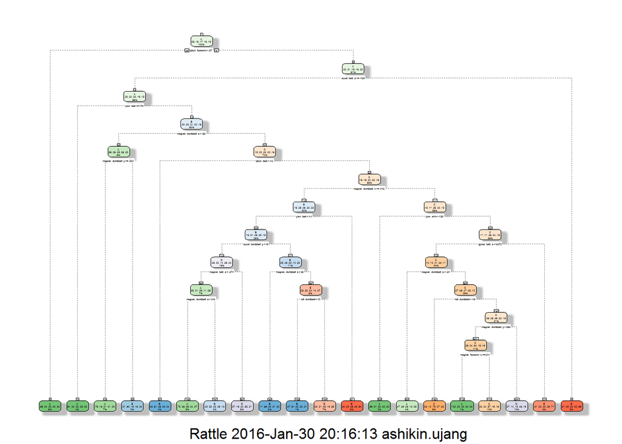

```r
set.seed(12345)
modFit1 <- rpart(classe ~ ., data=myTrainData, method="class")
fancyRpartPlot(modFit1)
```

```r
predict1 <- predict(modFit1, myTestData, type = "class")
confusionMatrix(predict1, myTestData$classe)
```

```
## Confusion Matrix and Statistics
##
##           Reference
## Prediction    A    B    C    D    E
##          A 2029  293   49   85   69
##          B   53  787   72   87   41
##          C   25   90  952  208  172
##          D  110  248  259  776  134
##          E   15  100   36  130 1026
##
## Overall Statistics
##
##                Accuracy : 0.7099
##                  95% CI : (0.6997, 0.7199)
##     No Information Rate : 0.2845
##     P-Value [Acc > NIR] : < 2.2e-16
##
##                   Kappa : 0.6319
##  Mcnemar's Test P-Value : < 2.2e-16
##
## Statistics by Class:
##
##                      Class: A Class: B Class: C Class: D Class: E
## Sensitivity            0.9091   0.5184   0.6959   0.6034   0.7115
## Specificity            0.9116   0.9600   0.9236   0.8855   0.9561
## Pos Pred Value         0.8036   0.7567   0.6579   0.5082   0.7850
## Neg Pred Value         0.9618   0.8926   0.9350   0.9193   0.9364
## Prevalence             0.2845   0.1935   0.1744   0.1639   0.1838
## Detection Rate         0.2586   0.1003   0.1213   0.0989   0.1308
## Detection Prevalence   0.3218   0.1326   0.1844   0.1946   0.1666
## Balanced Accuracy      0.9103   0.7392   0.8097   0.7445   0.8338
```

### Prediction with Generalized Boosted Regression

```r
fitControl1<-trainControl(method="cv", number=5, allowParallel=T, verbose=T)
gbmfit<-train(classe~.,data=myTrainData, method="gbm", trControl=fitControl1, verbose=F)
gbmfit$finalModel
```

```
## A gradient boosted model with multinomial loss function.
## 150 iterations were performed.
## There were 51 predictors of which 42 had non-zero influence.
```

```r
class(gbmfit)
```

```
## [1] "train"         "train.formula"
```

```r
predict2<-predict(gbmfit, newdata=myTrainData)
confusionMatrix(predict2, myTrainData$classe)
```

```
## Confusion Matrix and Statistics
##
##           Reference
## Prediction    A    B    C    D    E
##          A 3316   44    0    0    2
##          B   18 2192   44    9    9
##          C    6   38 1987   46   17
##          D    6    1   20 1865   22
##          E    2    4    3   10 2115
##
## Overall Statistics
##
##                Accuracy : 0.9744
##                  95% CI : (0.9714, 0.9772)
##     No Information Rate : 0.2843
##     P-Value [Acc > NIR] : < 2.2e-16
##
##                   Kappa : 0.9677
##  Mcnemar's Test P-Value : 1.877e-08
##
## Statistics by Class:
##
##                      Class: A Class: B Class: C Class: D Class: E
## Sensitivity            0.9904   0.9618   0.9674   0.9663   0.9769
## Specificity            0.9945   0.9916   0.9890   0.9950   0.9980
## Pos Pred Value         0.9863   0.9648   0.9489   0.9744   0.9911
## Neg Pred Value         0.9962   0.9908   0.9931   0.9934   0.9948
## Prevalence             0.2843   0.1935   0.1744   0.1639   0.1838
## Detection Rate         0.2816   0.1861   0.1687   0.1584   0.1796
## Detection Prevalence   0.2855   0.1929   0.1778   0.1625   0.1812
## Balanced Accuracy      0.9925   0.9767   0.9782   0.9807   0.9875
```

```r
predgbm<-predict(gbmfit, newdata=myTestData)
confusionMatrix(predgbm, myTestData$classe)
```

```
## Confusion Matrix and Statistics
##
##           Reference
## Prediction    A    B    C    D    E
##          A 2195   71    0    2    3
##          B   15 1400   42    6   14
##          C   12   40 1307   40   10
##          D    9    1   16 1227   23
##          E    1    6    3   11 1392
##
## Overall Statistics
##
##                Accuracy : 0.9586
##                  95% CI : (0.9539, 0.9629)
##     No Information Rate : 0.2845
##     P-Value [Acc > NIR] : < 2.2e-16
##
##                   Kappa : 0.9476
##  Mcnemar's Test P-Value : 7.775e-13
##
## Statistics by Class:
##
##                      Class: A Class: B Class: C Class: D Class: E
## Sensitivity            0.9834   0.9223   0.9554   0.9541   0.9653
## Specificity            0.9865   0.9878   0.9843   0.9925   0.9967
## Pos Pred Value         0.9665   0.9479   0.9276   0.9616   0.9851
## Neg Pred Value         0.9934   0.9815   0.9905   0.9910   0.9922
## Prevalence             0.2845   0.1935   0.1744   0.1639   0.1838
## Detection Rate         0.2798   0.1784   0.1666   0.1564   0.1774
## Detection Prevalence   0.2894   0.1882   0.1796   0.1626   0.1801
## Balanced Accuracy      0.9849   0.9550   0.9698   0.9733   0.9810
```

The accuracy is 96%, thus the predicted accuracy for the out-of-sample error is 4%.

### Prediction with Random Forests

```r
fitControl <- trainControl(method="cv", number=5, allowParallel=T, verbose=T)
rffit<-train(classe~.,data=myTrainData, method="rf", trControl=fitControl, verbose=F)
predict3<-predict(rffit, newdata=myTrainData)
confusionMatrix(predict3, myTrainData$classe)
```

```
## Confusion Matrix and Statistics
##
##           Reference
## Prediction    A    B    C    D    E
##          A 3348    0    0    0    0
##          B    0 2279    0    0    0
##          C    0    0 2054    0    0
##          D    0    0    0 1930    0
##          E    0    0    0    0 2165
##
## Overall Statistics
##
##                Accuracy : 1
##                  95% CI : (0.9997, 1)
##     No Information Rate : 0.2843
##     P-Value [Acc > NIR] : < 2.2e-16
##
##                   Kappa : 1
##  Mcnemar's Test P-Value : NA
##
## Statistics by Class:
##
##                      Class: A Class: B Class: C Class: D Class: E
## Sensitivity            1.0000   1.0000   1.0000   1.0000   1.0000
## Specificity            1.0000   1.0000   1.0000   1.0000   1.0000
## Pos Pred Value         1.0000   1.0000   1.0000   1.0000   1.0000
## Neg Pred Value         1.0000   1.0000   1.0000   1.0000   1.0000
## Prevalence             0.2843   0.1935   0.1744   0.1639   0.1838
## Detection Rate         0.2843   0.1935   0.1744   0.1639   0.1838
## Detection Prevalence   0.2843   0.1935   0.1744   0.1639   0.1838
## Balanced Accuracy      1.0000   1.0000   1.0000   1.0000   1.0000
```

```r
predrf<-predict(rffit, newdata=myTestData)
confusionMatrix(predrf, myTestData$classe)
```

```
## Confusion Matrix and Statistics
##
##           Reference
## Prediction    A    B    C    D    E
##          A 2231   17    0    0    0
##          B    0 1493   12    0    1
##          C    0    7 1353   14    0
##          D    1    0    3 1271    1
##          E    0    1    0    1 1440
##
## Overall Statistics
##
##                Accuracy : 0.9926
##                  95% CI : (0.9905, 0.9944)
##     No Information Rate : 0.2845
##     P-Value [Acc > NIR] : < 2.2e-16
##
##                   Kappa : 0.9906
##  Mcnemar's Test P-Value : NA
##
## Statistics by Class:
##
##                      Class: A Class: B Class: C Class: D Class: E
## Sensitivity            0.9996   0.9835   0.9890   0.9883   0.9986
## Specificity            0.9970   0.9979   0.9968   0.9992   0.9997
## Pos Pred Value         0.9924   0.9914   0.9847   0.9961   0.9986
## Neg Pred Value         0.9998   0.9961   0.9977   0.9977   0.9997
## Prevalence             0.2845   0.1935   0.1744   0.1639   0.1838
## Detection Rate         0.2843   0.1903   0.1724   0.1620   0.1835
## Detection Prevalence   0.2865   0.1919   0.1751   0.1626   0.1838
## Balanced Accuracy      0.9983   0.9907   0.9929   0.9938   0.9992
```

The accuracy is 99%, thus the predicted accuracy for the out-of-sample error is 1%. We choose **Random Forests** because it produce better results. Below is the formula to submit as answers for this project.

```r
predictpmlTesting<-predict(rffit, newdata=pmlTesting)
# Output for the prediction of the 20 cases provided
predictpmlTesting
```

```
##  [1] B A B A A E D B A A B C B A E E A B B B
## Levels: A B C D E
```

```r
pml_write_files = function(x){
  n = length(x)
  for(i in 1:20){
    filename = paste0("problem_id_",i,".txt")
    write.table(x[i],file=filename,quote=FALSE,row.names=FALSE,col.names=FALSE)
  }
}
pml_write_files(predictpmlTesting)
```